# (Classification) Trees, Forest, and Boosting

GAO Zheng

April 6, 2017

This is a tutorial on classification trees and boosted trees, based on LOH Wei-yin’s review article on [Classification and regression trees](http://www.stat.wisc.edu/~loh/treeprogs/guide/wires11.pdf), Scott Fortmann-Roe’s article on [Bias-Variance Trade-off](http://scott.fortmann-roe.com/docs/BiasVariance.html) and CHEN Tianqi’s [XGBoost: A Scalable Tree Boosting System](https://arxiv.org/pdf/1603.02754.pdf).

We will discuss basic ideas, as well as implementation details.

# Classification Trees

Classification and regression trees are machine-learning methods for constructing prediction models from data. The models are obtained by recursively partitioning the data space and fitting a simple prediction model within each partition. As a result, the partitioning can be represented graphically as a decision tree. Classification trees are designed for dependent variables that take a finite number of unordered values, with prediction error measured in terms of misclassification cost. Regression trees are for dependent variables that take continuous or ordered discrete values, with prediction error typically measured by the squared difference between the observed and predicted values.

## How large should a tree be grown?

You can always keep on splitting with binary nodes until you get 0 error. However, fitting a very complex tree (as with any other model) is not a good idea.

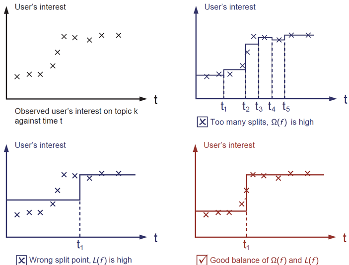

The basic principles of model selection is that the more complex a model is, the higher the variance your trained model will be, because the randomness in the training data manifests in the fitting process.

The simpler your model is, the more constrained the model is. A simpler model has little room to wiggle and twist to fit the training data. There lies the possibility of bias, in that the model may be insufficient to describe the truth.

A good model should be a good trade-off between bias and vairance: not too complicated, but not to overly-simplified.

There are ways that people have came up to perform model selection, many of them based on the same idea, and summarize the trade-off in a number that is of the form “bias + variance”.

We resort to cross validation in model choices in this tutorial. It is an automatic, and easy-to-understand strategy that we discussed in the last tutorial.

Cross-validation is built-in in the package `rpart`, which we will be using in the next section.

## An example

Let’s illustrate this with an example, and try to understand the output.

```r
head(iris)
```

```
##   Sepal.Length Sepal.Width Petal.Length Petal.Width Species
## 1          5.1         3.5          1.4         0.2  setosa
## 2          4.9         3.0          1.4         0.2  setosa
## 3          4.7         3.2          1.3         0.2  setosa
## 4          4.6         3.1          1.5         0.2  setosa
## 5          5.0         3.6          1.4         0.2  setosa
## 6          5.4         3.9          1.7         0.4  setosa
```

```r
library(rpart)
(fit <- rpart(Species ~ ., data = iris, method = "class"))
```

```
## n= 150
##
## node), split, n, loss, yval, (yprob)
##       * denotes terminal node
##
## 1) root 150 100 setosa (0.33333333 0.33333333 0.33333333)
##   2) Petal.Length< 2.45 50   0 setosa (1.00000000 0.00000000 0.00000000) *
##   3) Petal.Length>=2.45 100  50 versicolor (0.00000000 0.50000000 0.50000000)
##     6) Petal.Width< 1.75 54   5 versicolor (0.00000000 0.90740741 0.09259259) *
##     7) Petal.Width>=1.75 46   1 virginica (0.00000000 0.02173913 0.97826087) *
```

```r
summary(fit) # detailed summary of splits
```

```
## Call:
## rpart(formula = Species ~ ., data = iris, method = "class")
##   n= 150
##
##     CP nsplit rel error xerror       xstd
## 1 0.50      0      1.00   1.19 0.04959167
## 2 0.44      1      0.50   0.72 0.06118823
## 3 0.01      2      0.06   0.09 0.02908608
##
## Variable importance
##  Petal.Width Petal.Length Sepal.Length  Sepal.Width
##           34           31           21           14
##
## Node number 1: 150 observations,    complexity param=0.5
##   predicted class=setosa      expected loss=0.6666667  P(node) =1
##     class counts:    50    50    50
##    probabilities: 0.333 0.333 0.333
##   left son=2 (50 obs) right son=3 (100 obs)
##   Primary splits:
##       Petal.Length < 2.45 to the left,  improve=50.00000, (0 missing)
##       Petal.Width  < 0.8  to the left,  improve=50.00000, (0 missing)
##       Sepal.Length < 5.45 to the left,  improve=34.16405, (0 missing)
##       Sepal.Width  < 3.35 to the right, improve=19.03851, (0 missing)
##   Surrogate splits:
##       Petal.Width  < 0.8  to the left,  agree=1.000, adj=1.00, (0 split)
##       Sepal.Length < 5.45 to the left,  agree=0.920, adj=0.76, (0 split)
##       Sepal.Width  < 3.35 to the right, agree=0.833, adj=0.50, (0 split)
##
## Node number 2: 50 observations
##   predicted class=setosa      expected loss=0  P(node) =0.3333333
##     class counts:    50     0     0
##    probabilities: 1.000 0.000 0.000
##
## Node number 3: 100 observations,    complexity param=0.44
##   predicted class=versicolor  expected loss=0.5  P(node) =0.6666667
##     class counts:     0    50    50
##    probabilities: 0.000 0.500 0.500
##   left son=6 (54 obs) right son=7 (46 obs)
##   Primary splits:
##       Petal.Width  < 1.75 to the left,  improve=38.969400, (0 missing)
##       Petal.Length < 4.75 to the left,  improve=37.353540, (0 missing)
##       Sepal.Length < 6.15 to the left,  improve=10.686870, (0 missing)
##       Sepal.Width  < 2.45 to the left,  improve= 3.555556, (0 missing)
##   Surrogate splits:
##       Petal.Length < 4.75 to the left,  agree=0.91, adj=0.804, (0 split)
##       Sepal.Length < 6.15 to the left,  agree=0.73, adj=0.413, (0 split)
##       Sepal.Width  < 2.95 to the left,  agree=0.67, adj=0.283, (0 split)
##
## Node number 6: 54 observations
##   predicted class=versicolor  expected loss=0.09259259  P(node) =0.36
##     class counts:     0    49     5
##    probabilities: 0.000 0.907 0.093
##
## Node number 7: 46 observations
##   predicted class=virginica   expected loss=0.02173913  P(node) =0.3066667
##     class counts:     0     1    45
##    probabilities: 0.000 0.022 0.978
```

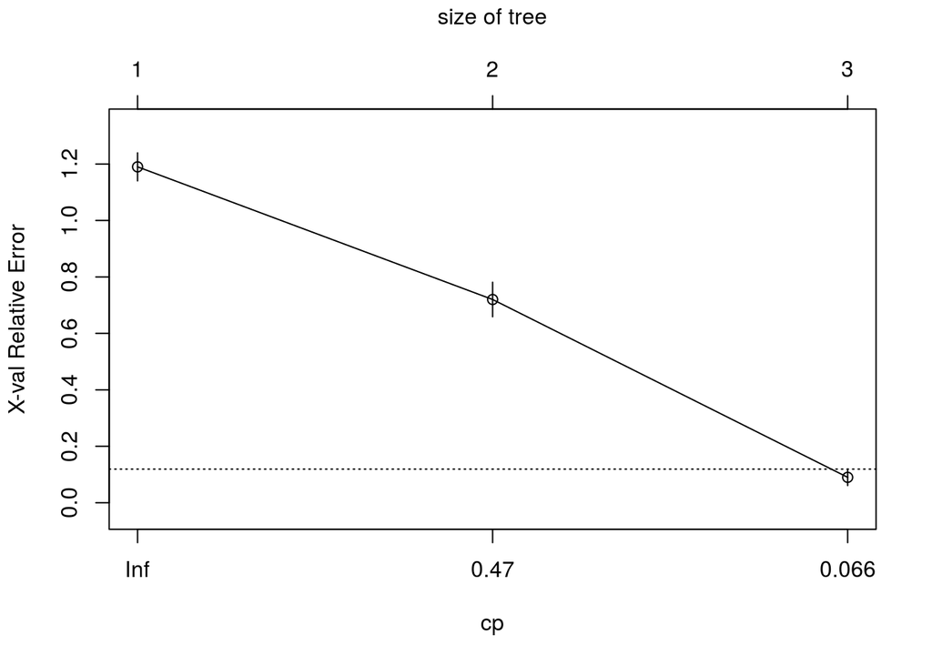

```r
plotcp(fit) # visualize cross-validation results
```

```r
printcp(fit) # display the results
```

```
##
## Classification tree:
## rpart(formula = Species ~ ., data = iris, method = "class")
##
## Variables actually used in tree construction:
## [1] Petal.Length Petal.Width
##
## Root node error: 100/150 = 0.66667
##
## n= 150
##
##     CP nsplit rel error xerror     xstd
## 1 0.50      0      1.00   1.19 0.049592
## 2 0.44      1      0.50   0.72 0.061188
## 3 0.01      2      0.06   0.09 0.029086
```

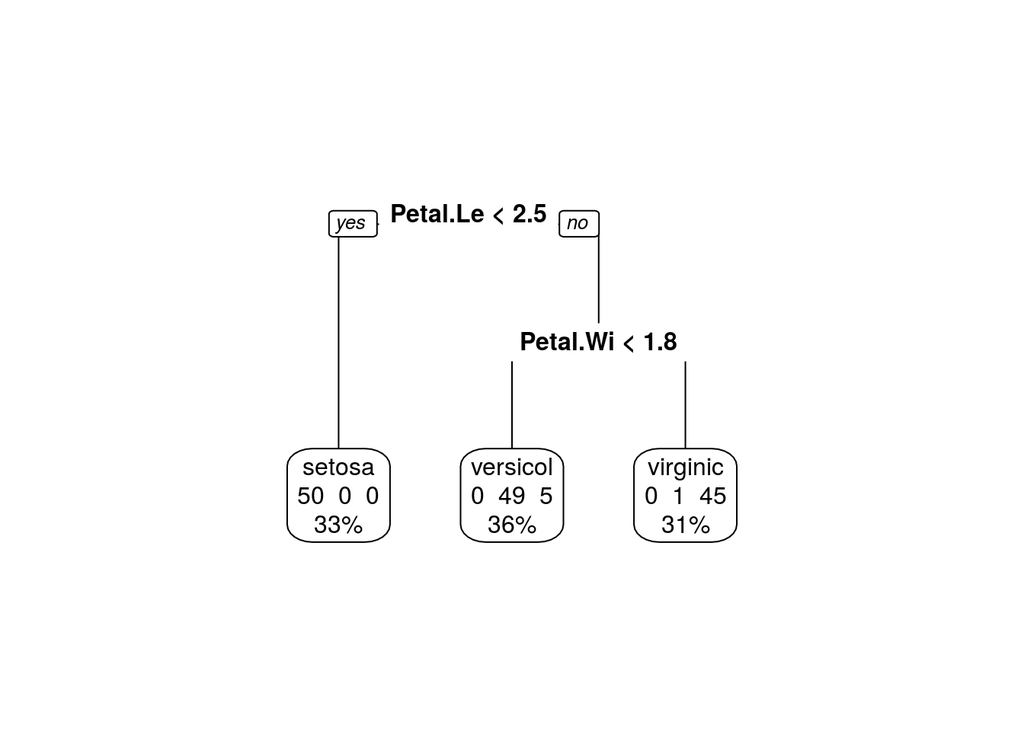

```r
# install.packages("rpart.plot")
library(rpart.plot)
rpart.plot::prp(fit, extra = 101, fallen.leaves = T)
```

Let’s look at the result of the splits visually

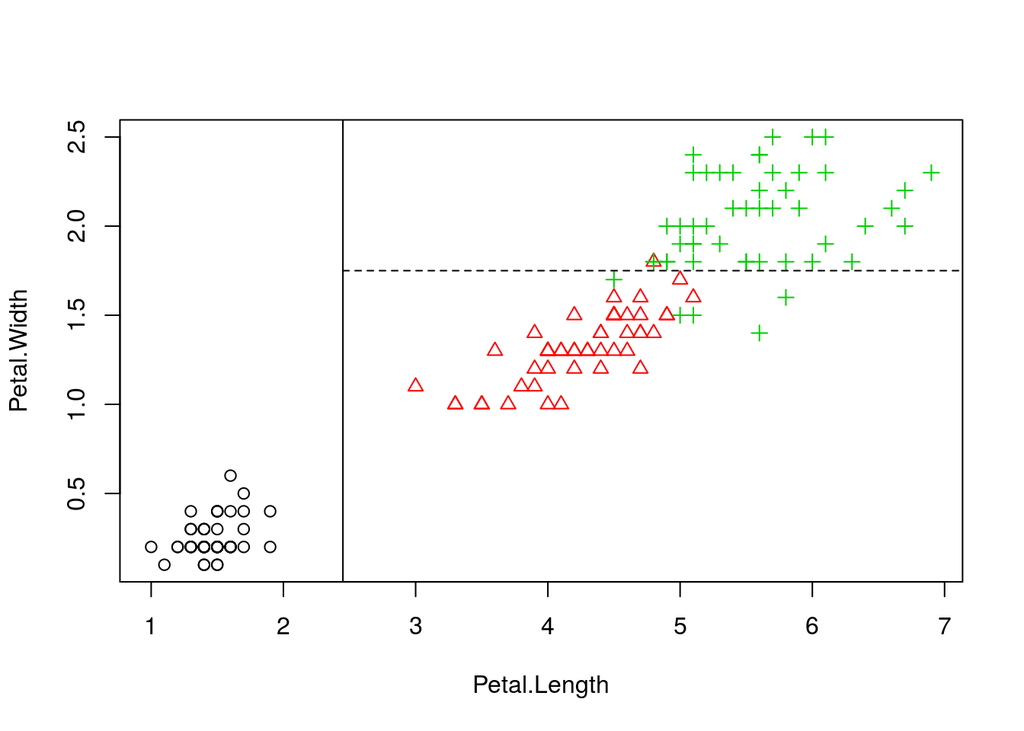

```r
plot(iris[,3:4], col = as.numeric(iris$Species), pch = as.numeric(iris$Species))
abline(v = 2.45); lines(c(2.45, 8), c(1.75, 1.75), lty = 2)
```

## Lending Club data

Now the real data. We fit a classification tree to the Lending Club Loan data.

```r
# Classification Tree with rpart
library(rpart)
# Read data
LCdata <- read.csv("../data/LoanStatsTraining.csv", header = T)
```

```r
LCdata$isBadLoan <- as.factor(LCdata$isBadLoan)
# grow tree
fit <- rpart(isBadLoan ~ sub_grade + dti + loan_amnt,
    method = "class", data = LCdata)

summary(fit) # detailed summary of splits
```

```
## Call:
## rpart(formula = isBadLoan ~ sub_grade + dti + loan_amnt, data = LCdata,
##     method = "class")
##   n= 31829
##
##   CP nsplit rel error xerror xstd
## 1  0      0         1      0    0
##
## Node number 1: 31829 observations
##   predicted class=0  expected loss=0.1432027  P(node) =1
##     class counts: 27271  4558
##    probabilities: 0.857 0.143
```

Remember this is an unbalanced dataset, the default criteria for making splits weighs two classes equally. We need to specify the relative weights.

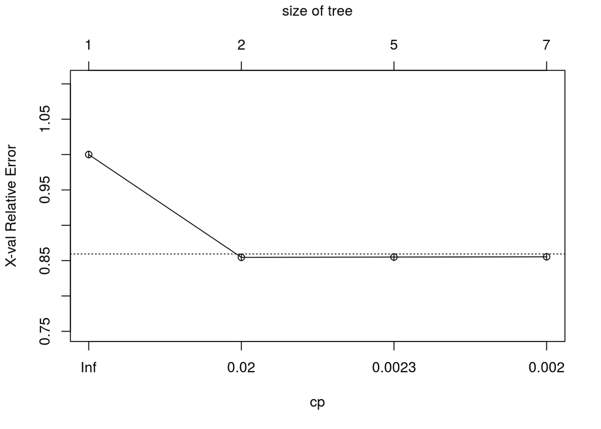

```r
# grow tree
fit <- rpart(isBadLoan ~ sub_grade + dti + loan_amnt, weights = 1 + (isBadLoan == 1) * 4,
    method = "class", data = LCdata, control = rpart.control(cp = 0.002))

# summary(fit) # detailed summary of splits
plotcp(fit)
```

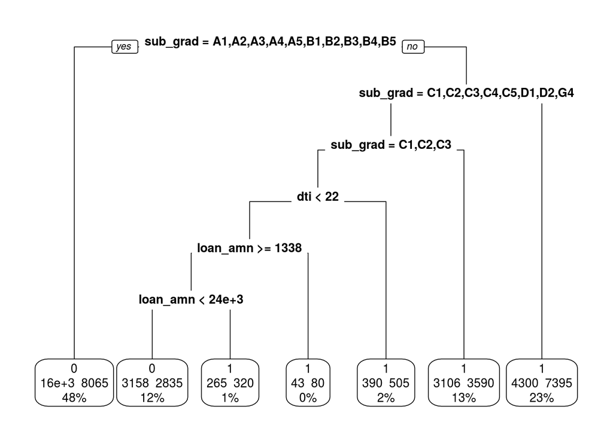

```r
rpart.plot::prp(fit, extra = 101, fallen.leaves = T)
```

Notice that the cross-validation error actually increases when the number of terminal nodes increases (we set the termination criteria to be cp = 0.002). We have over-fitted to the data. CV error shows that the optimal split is when termination criteria is at cp = 0.02.

Let’s re-fit the tree using the optimal value from cross-validation

```r
# grow tree
fit <- rpart(isBadLoan ~ sub_grade + dti + loan_amnt, weights = 1 + (isBadLoan == 1) * 4,
    method = "class", data = LCdata, control = rpart.control(cp = 0.02))

summary(fit) # detailed summary of splits
```

```
## Call:
## rpart(formula = isBadLoan ~ sub_grade + dti + loan_amnt, data = LCdata,
##     weights = 1 + (isBadLoan == 1) * 4, method = "class", control = rpart.control(cp = 0.02))
##   n= 31829
##
##          CP nsplit rel error    xerror        xstd
## 1 0.1519526      0 1.0000000 1.0000000 0.004889096
## 2 0.0200000      1 0.8480474 0.8577885 0.004789647
##
## Variable importance
## sub_grade loan_amnt       dti
##        85        10         5
##
## Node number 1: 31829 observations,    complexity param=0.1519526
##   predicted class=0  expected loss=0.4552446  P(node) =1
##     class counts: 27271 22790
##    probabilities: 0.545 0.455
##   left son=2 (17622 obs) right son=3 (14207 obs)
##   Primary splits:
##       sub_grade splits as  LLLLLLLLLLRRRRRRRRRRRRRRRRRRRRRRRRR, improve=1340.88000, (0 missing)
##       loan_amnt < 15187.5 to the left,  improve= 179.89590, (0 missing)
##       dti       < 11.535  to the left,  improve=  85.17738, (0 missing)
##   Surrogate splits:
##       loan_amnt < 13062.5 to the left,  agree=0.578, adj=0.123, (0 split)
##       dti       < 10.665  to the left,  agree=0.547, adj=0.057, (0 split)
##
## Node number 2: 17622 observations
##   predicted class=0  expected loss=0.3350087  P(node) =0.4808933
##     class counts: 16009  8065
##    probabilities: 0.665 0.335
##
## Node number 3: 14207 observations
##   predicted class=1  expected loss=0.4333705  P(node) =0.5191067
##     class counts: 11262 14725
##    probabilities: 0.433 0.567
```

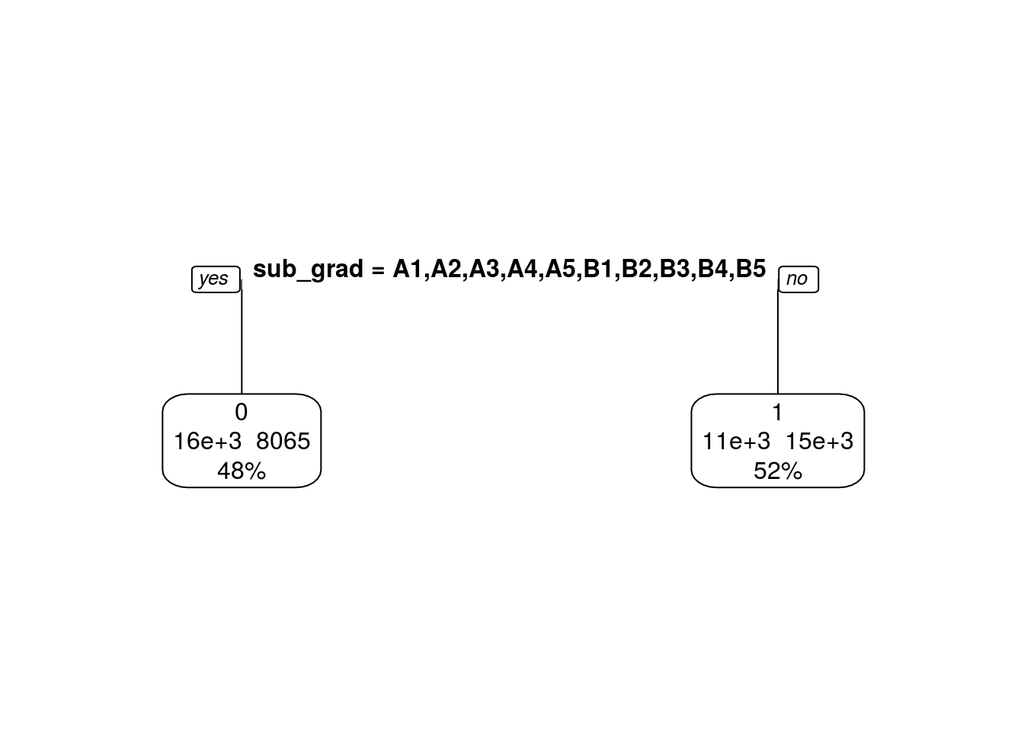

```r
rpart.plot::prp(fit, extra = 101, fallen.leaves = T)
```

It seems that the best tree grown out of the three co-variates is just a one-split decision.

# Forest

Bagging and other resampling techniques can be used to reduce the variance in model predictions. In bagging (**B**ootstrap **Agg**regat**ing**), numerous replicates of the original data set are created using random selection with replacement. Each derivative data set is then used to construct a new model and the models are gathered together into an ensemble. To make a prediction, all of the models in the ensemble are polled and their results are averaged.

One powerful modeling algorithm that makes good use of bagging is Random Forests. Random Forests works by training numerous decision trees each based on a different resampling of the original training data. In Random Forests the bias of the full model is equivalent to the bias of a single decision tree (which itself has high variance). By creating many of these trees, in effect a “forest”, and then averaging them the variance of the final model can be greatly reduced over that of a single tree. In practice the only limitation on the size of the forest is computing time as an infinite number of trees could be trained without ever increasing bias and with a continual (if asymptotically declining) decrease in the variance.

## Details

Every time we draw 63.2% of all the samples (the expected number of distinct items in a bootstrap sample, or otherwise specified by the user), and `mtry` number of co-variates (chosen by the user), and perform the same tree fitting procedure `ntree` times (500, or otherwise specified by the user).

Each tree provides a prediction (clsasification / regression) for the samples chosen.

The final prediction is taken as the aggregated votes (in classification) or average predicted value (in regression).

## Illustration with `iris`

```r
# install.packages("randomForest")
library(randomForest)
?randomForest
(fitForest <- randomForest(Species ~ ., data = iris, mtry = 4))
```

```
##
## Call:
##  randomForest(formula = Species ~ ., data = iris, mtry = 4)
##                Type of random forest: classification
##                      Number of trees: 500
## No. of variables tried at each split: 4
##
##         OOB estimate of  error rate: 4.67%
## Confusion matrix:
##            setosa versicolor virginica class.error
## setosa         50          0         0        0.00
## versicolor      0         47         3        0.06
## virginica       0          4        46        0.08
```

```r
importance(fitForest)
```

```
##              MeanDecreaseGini
## Sepal.Length         1.232655
## Sepal.Width          1.339946
## Petal.Length        45.409059
## Petal.Width         51.321886
```

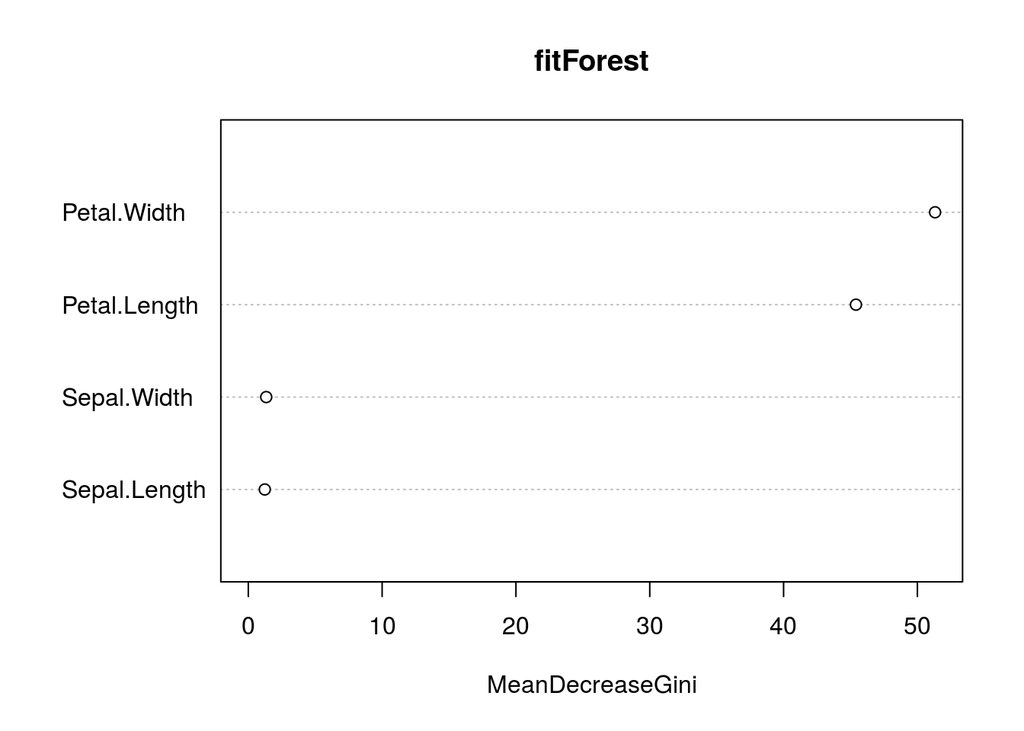

```r
varImpPlot(fitForest)
```

Most of the splits that generate a big gain (in terms of [Gini impurity](https://en.wikipedia.org/wiki/Decision_tree_learning#Gini_impurity)) is made on the `Petal.Width` and `Petal.Length` variables, They show up as the most important variables for categorization of the Spiecies.

We can look at a sample of the predictions

```r
(fitForest$votes[100:110,])
```

```
##     setosa  versicolor   virginica
## 100      0 1.000000000 0.000000000
## 101      0 0.000000000 1.000000000
## 102      0 0.016042781 0.983957219
## 103      0 0.000000000 1.000000000
## 104      0 0.000000000 1.000000000
## 105      0 0.000000000 1.000000000
## 106      0 0.000000000 1.000000000
## 107      0 0.994764398 0.005235602
## 108      0 0.000000000 1.000000000
## 109      0 0.005181347 0.994818653
## 110      0 0.000000000 1.000000000
```

Some of them are classified with high probability into one of the groups, some of them are less clear (but still very close to 0/1). The classes in this example is well-seperated.

# Boosted trees

Another idea to aggregate trees is Boosting.

Rather than fitting trees in parallel, we start with a tree that is fitted on all the data. In the next iteration we focus on the samples that were misclassified in the last round.

For example if we wish to predict if a user likes computer games, the first tree grown (tree1) splits on age and gender, and terminates. However, mistakes are made on some of the samples, e.g. the old senior citizen, who actually like video games, were misclassified. Then in the next round of fitting, we try to make that right by placing more weights on the miscalssified samples.

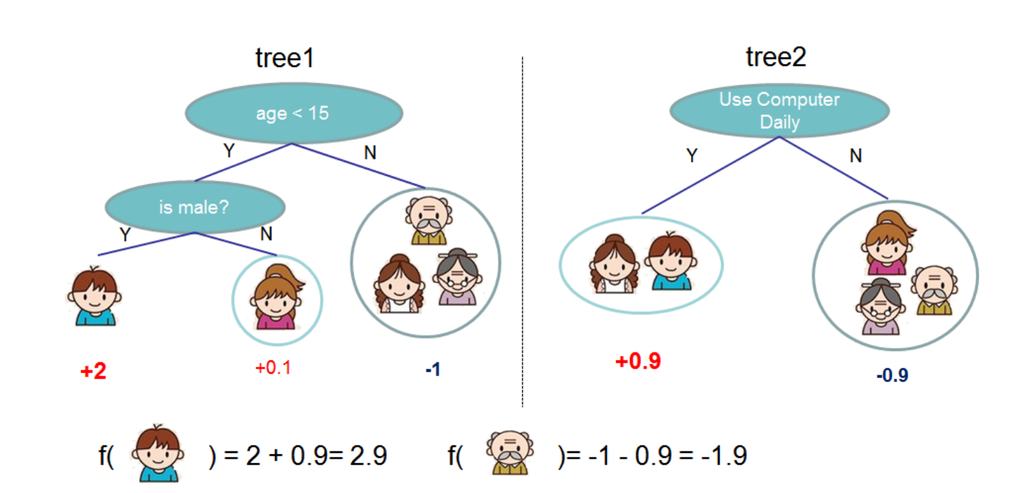

We will follow [the official tutorial on XGboost] (http://xgboost.readthedocs.io/en/latest/R-package/xgboostPresentation.html) together.